# 检验统计量从哪来：比值、正态族与分布拟合

最后更新：2026-07-25 21:49 EDT

$t$ 分布、$F$ 分布、$\chi^2$——这些分布在自然界里几乎见不到，因为它们**不是自然过程的产物，而是统计学家造出来的量**：为了在样本里做推断，把若干个正态量按特定方式**除**在一起，得到一个分布已知、可查表的检验统计量。

$$t = \frac{Z}{\sqrt{\chi^2_k/k}}, \qquad
F = \frac{\chi^2_m/m}{\chi^2_n/n}$$

本文做两件事：先看这些**比值**怎么从正态族里被构造出来（顺带画清正态族内部的关系），再动手做一次**分布拟合与模型选择**——拿到真实数据时，怎么系统地挑出最合适的分布。

# 1 比值：$t$ 与 $F$ 从哪里来

前两节的分布描述”世界本身”。这一节的分布描述**“我们对世界的不确定性”**——它们不是数据的分布，而是**统计量的分布**。

当我们用样本估计总体参数时，样本均值服从正态（CLT），但样本方差引入额外随机性。比值运算正是用来处理这个问题。

## 1.1 t 分布：Normal / sqrt(Chi-squared / k)

$$t_k = \frac{Z}{\sqrt{\chi^2_k / k}},
\quad Z \perp \chi^2_k$$

**现实意义**：当你用样本均值估计总体均值，但不知道总体方差时，$\bar{X}$ 的标准化量服从 $t(n-1)$ 而非 $N(0,1)$。

t 分布比正态**尾部更重**——直觉：分母是一个随机量，有时偏小，就把比值推向极端。自由度 $k \to \infty$ 时趋向正态（因为样本方差趋向稳定）。

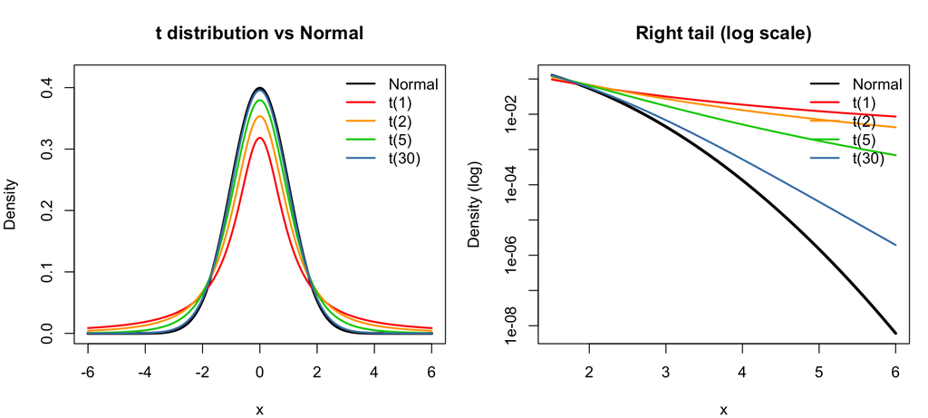

```r
x_seq <- seq(-6, 6, length.out = 600)
par(mfrow = c(1, 2), mar = c(4, 4, 3.5, 1))

# Density comparison
cols_t <- c("red", "orange", "green3", "steelblue")
dfs    <- c(1, 2, 5, 30)
plot(x_seq, dnorm(x_seq), type = "l", col = "black", lwd = 3,
     main = "t distribution vs Normal", xlab = "x", ylab = "Density",
     ylim = c(0, 0.42))
for (i in seq_along(dfs))
  lines(x_seq, dt(x_seq, dfs[i]), col = cols_t[i], lwd = 2)
legend("topright", c("Normal", paste0("t(", dfs, ")")),
       col = c("black", cols_t), lwd = 2, bty = "n")

# Right tail (log scale)
x_tail <- x_seq[x_seq > 1.5]
plot(x_tail, dnorm(x_tail), type = "l", col = "black", lwd = 3,
     main = "Right tail (log scale)", xlab = "x", ylab = "Density (log)", log = "y")
for (i in seq_along(dfs))
  lines(x_tail, dt(x_tail, dfs[i]), col = cols_t[i], lwd = 2)
legend("topright", c("Normal", paste0("t(", dfs, ")")),
       col = c("black", cols_t), lwd = 2, bty = "n")
```

### 1.1.1 从零模拟 t 分布

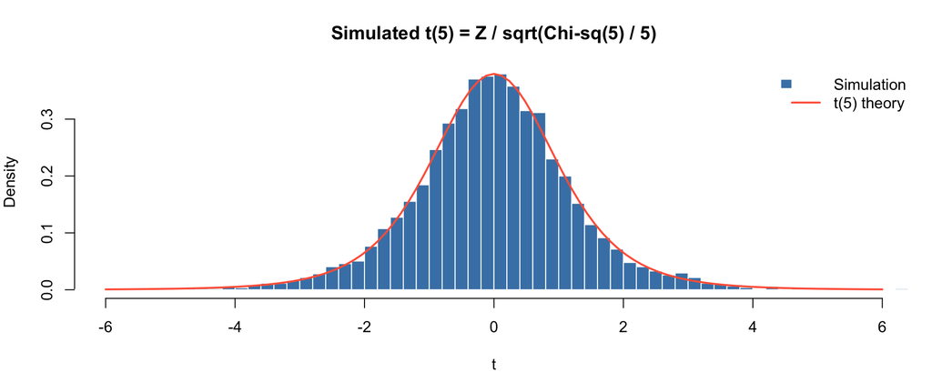

```r
k <- 5; n_sim <- 10000
Z    <- rnorm(n_sim)
chi2 <- rowSums(matrix(rnorm(n_sim * k)^2, nrow = n_sim))
t_sim <- Z / sqrt(chi2 / k)

par(mfrow = c(1, 1), mar = c(4, 4, 3.5, 1))
hist(t_sim, breaks = 100, col = "steelblue", freq = FALSE, border = "white",
     main = paste0("Simulated t(", k, ") = Z / sqrt(Chi-sq(", k, ") / ", k, ")"),
     xlab = "t", xlim = c(-6, 6))
curve(dt(x, df = k), add = TRUE, col = "tomato", lwd = 2)
legend("topright", c("Simulation", paste0("t(", k, ") theory")),
       fill = c("steelblue", NA), border = c("white", NA),
       lty = c(NA, 1), col = c(NA, "tomato"), lwd = c(NA, 2), bty = "n")
```

## 1.2 F 分布：两个 Chi-squared 之比

$$F_{m,n} = \frac{\chi^2_m / m}{\chi^2_n /
n}$$

F 分布是 ANOVA 的基础：当零假设成立时，两个方差估计量的比值服从 F 分布。

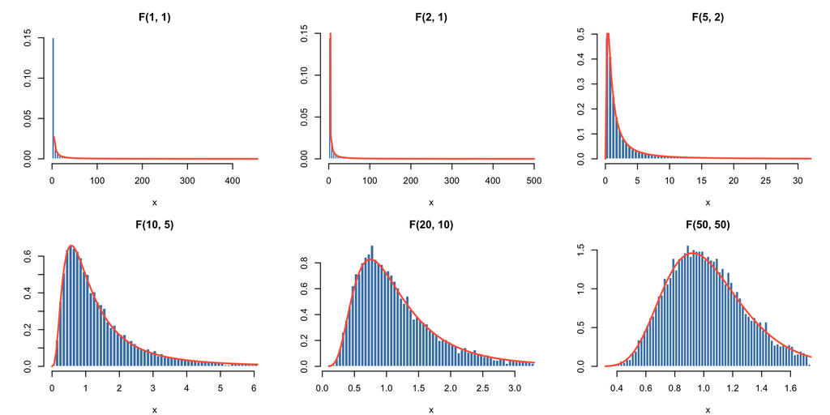

```r
n_sim <- 10000
par(mfrow = c(2, 3), mar = c(4, 4, 3, 1))
for (params in list(c(1,1), c(2,1), c(5,2), c(10,5), c(20,10), c(50,50))) {
  m <- params[1]; n <- params[2]
  chi2_m <- rowSums(matrix(rnorm(n_sim * m)^2, nrow = n_sim))
  chi2_n <- rowSums(matrix(rnorm(n_sim * n)^2, nrow = n_sim))
  f_sim  <- (chi2_m / m) / (chi2_n / n)

  xlim_val <- quantile(f_sim, 0.97)
  hist(f_sim[f_sim <= xlim_val], breaks = 80, col = "steelblue",
       freq = FALSE, border = "white",
       main = paste0("F(", m, ", ", n, ")"), xlab = "x", ylab = "")
  curve(df(x, df1 = m, df2 = n), add = TRUE, col = "tomato", lwd = 2)
}
```

## 1.3 正态族关系图

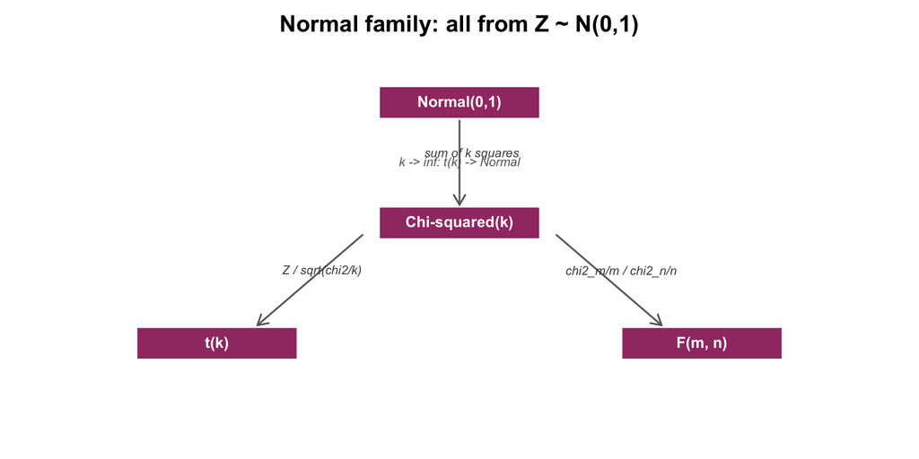

```r
par(mar = c(1, 1, 2, 1))
plot(NA, xlim = c(0, 10), ylim = c(0, 6), axes = FALSE, bty = "n",
     xlab = "", ylab = "", main = "Normal family: all from Z ~ N(0,1)")

draw_box <- function(x, y, label, col = "#A23B72", w = 2, h = 0.55) {
  rect(x-w/2, y-h/2, x+w/2, y+h/2, col = col, border = "white", lwd = 2)
  text(x, y, label, col = "white", font = 2, cex = 0.8)
}
arr <- function(x0, y0, x1, y1, lab = "") {
  arrows(x0, y0, x1, y1, length = 0.10, lwd = 1.5, col = "gray40")
  text((x0+x1)/2 + 0.15, (y0+y1)/2 + 0.15,
       lab, cex = 0.65, col = "gray30", font = 3)
}

draw_box(5, 5.3, "Normal(0,1)")
draw_box(5, 3.3, "Chi-squared(k)")
draw_box(2, 1.3, "t(k)")
draw_box(8, 1.3, "F(m, n)")

arr(5, 5, 5, 3.6, "sum of k squares")
arr(3.8, 3.1, 2.5, 1.6, "Z / sqrt(chi2/k)")
arr(6.2, 3.1, 7.5, 1.6, "chi2_m/m / chi2_n/n")
text(5, 4.3, "k -> inf: t(k) -> Normal", cex = 0.65, col = "gray40", font = 3)
```

# 2 综合实战：fitdistrplus 模型选择

理论之外的实操：给定一批数据，如何系统地选择最合适的分布？

**决策逻辑**：

1. **数据特征** → 缩小候选范围
   - 非负且右偏？→ Exp, Gamma, Weibull, LogNormal
   - 对称或近似对称？→ Normal, t, Logistic
   - 有界区间？→ Beta, Uniform
   - 极端值异常频繁？→ Pareto, 重尾分布
2. **Cullen-Frey 图**（`descdist`）→ 用偏度²和峰度在分布地图上定位
3. **竞争拟合**（`fitdist`）→ MLE 拟合多个候选
4. **诊断图 + 统计量**（`denscomp/qqcomp` + `gofstat`）→ 选最佳
5. **不确定性**（`bootdist`）→ 参数有多可靠？

工具链：`descdist` → `fitdist` → `gofstat` → `bootdist`

## 2.1 Cullen-Frey 图：快速筛选候选分布

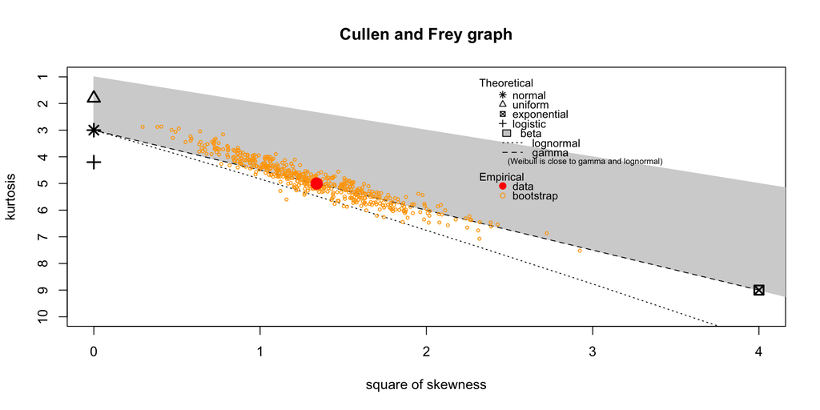

```
## summary statistics
## ------
## min:  0.1359059   max:  5.477676
## median:  1.383201
## mean:  1.526802
## estimated sd:  0.8804766
## estimated skewness:  1.157464
## estimated kurtosis:  5.004582
```

```r
true_data <- rgamma(500, shape = 3, rate = 2)
descdist(true_data, boot = 500)
```

## 2.2 多分布竞争拟合

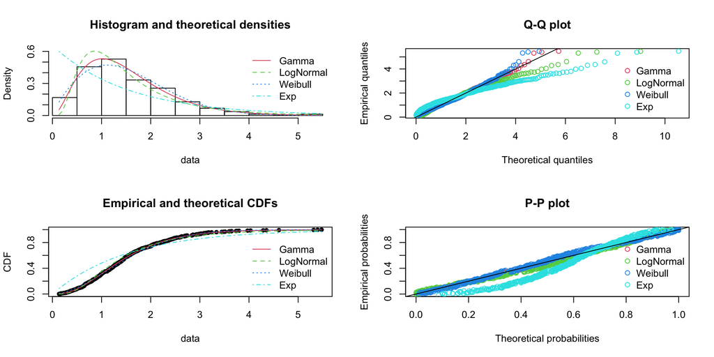

```r
f_gamma   <- fitdist(true_data, "gamma")
f_lnorm   <- fitdist(true_data, "lnorm")
f_weibull <- fitdist(true_data, "weibull")
f_exp     <- fitdist(true_data, "exp")

plot_labels <- c("Gamma", "LogNormal", "Weibull", "Exp")

par(mfrow = c(2, 2))
denscomp(list(f_gamma, f_lnorm, f_weibull, f_exp), legendtext = plot_labels)
qqcomp  (list(f_gamma, f_lnorm, f_weibull, f_exp), legendtext = plot_labels)
cdfcomp (list(f_gamma, f_lnorm, f_weibull, f_exp), legendtext = plot_labels)
ppcomp  (list(f_gamma, f_lnorm, f_weibull, f_exp), legendtext = plot_labels)
```

## 2.3 拟合优度统计量

```r
gofstat(list(f_gamma, f_lnorm, f_weibull, f_exp),
        fitnames = plot_labels)
```

```
## Goodness-of-fit statistics
##                                   Gamma  LogNormal    Weibull       Exp
## Kolmogorov-Smirnov statistic 0.02266712 0.06166806 0.04431622  0.219664
## Cramer-von Mises statistic   0.03600106 0.42683916 0.17644062  8.113297
## Anderson-Darling statistic   0.21021156 2.70336108 1.07675181 43.690085
##
## Goodness-of-fit criteria
##                                   Gamma LogNormal  Weibull      Exp
## Akaike's Information Criterion 1177.849  1210.398 1190.335 1425.176
## Bayesian Information Criterion 1186.278  1218.827 1198.765 1429.390
```

## 2.4 参数不确定性：Bootstrap

```r
b_gamma <- bootdist(f_gamma, niter = 500)
summary(b_gamma)
```

```
## Parametric bootstrap medians and 95% percentile CI
##         Median     2.5%    97.5%
## shape 3.019763 2.659449 3.350903
## rate  1.981738 1.715223 2.241929
```

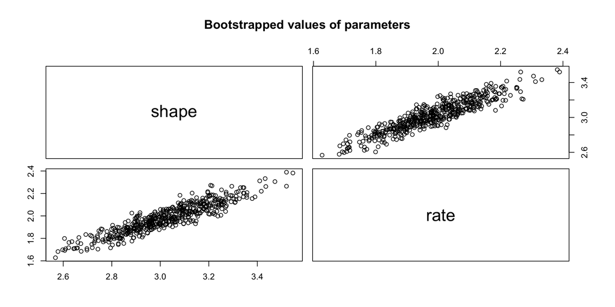

```r
plot(b_gamma)
```